# Prediction Assignment Writeup

### Model Specification

A random forest model was specified using all predictors which remained after data censoring. The `caret` package was used at first, but it ran very slowly, and so the `randomForest()` function from the package `randomForest` was used directly.

```r
rfMod <- randomForest(classe~., data=train, importance=T)
```

There is no need for cross-validation to get an unbiased estimate of the test set error when using a random forest model (Breiman 2001), hence the entire training data set was used to fit the model. We can then assess error by looking at the out-of-bag (OOB) error rate in the model object.

```r
rfMod
```

```
##
## Call:
##  randomForest(formula = classe ~ ., data = train, importance = T)
##                Type of random forest: classification
##                      Number of trees: 500
## No. of variables tried at each split: 7
##
##         OOB estimate of  error rate: 0.3%
## Confusion matrix:
##      A    B    C    D    E class.error
## A 5578    1    0    0    1   0.0003584
## B   11 3783    3    0    0   0.0036871
## C    0   12 3408    2    0   0.0040912
## D    0    0   21 3193    2   0.0071517
## E    0    0    2    3 3602   0.0013862
```

We can see here that there is < 1% OOB error rate, which is estimated on the OOB sample for each tree. This would seem satisfactory.

### Variable Importance

A matrix of variable importance values can be retrieved from the random forest model as follows:

```r
imp <- importance(rfMod)
```

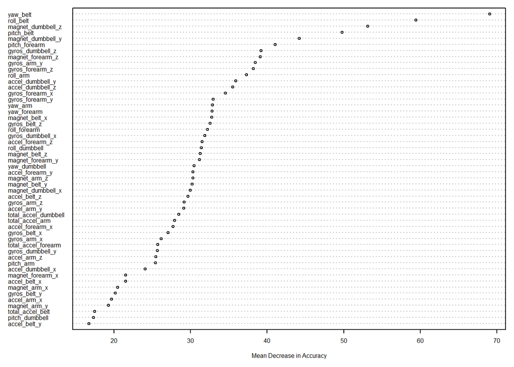

### Predictions on Test Dataset

Classification predictions were made on the tests data set using the random forest model.

```r
pred <- predict(rfMod, test)
```

The following output was obtained.

```r
# 1  2  3  4  5  6  7  8  9 10 11 12 13 14 15 16 17 18 19 20
# B  A  B  A  A  E  D  B  A  A  B  C  B  A  E  E  A  B  B  B
#Levels: A B C D E
```

### References

Breiman, L. (2001) Random Forests. Machine Learning, 45, 5-32  
Velloso, E.; Bulling, A.; Gellersen, H.; Ugulino, W.; Fuks, H. (2013) Qualitative Activity Recognition of Weight Lifting Exercises. Proceedings of 4th International Conference in Cooperation with SIGCHI (Augmented Human ’13) . Stuttgart, Germany: ACM SIGCHI.